# Curation of ZDTBCG motifs

Melanie (1028-02098-001-001)

August 04, 2022

# Introduction

The goal of this analysis is to curate motifs found by the `ZDTBCG` TF-MoDISco run such that there are no redundancies due palindromes, sequence similarity, overlapping peak regions etc.

Here, we will use the `fold1` optimized model trained to map the TF-MoDISco logos of each motif that is relevant to the TFs trained on the model.

# Computational Setup

```r
#Standard packages
library(rtracklayer) ; library(GenomicRanges); library(magrittr) ; library(Biostrings)
library(ggplot2) ; library(reshape2); library(plyranges); library(Rsamtools)
library(dplyr); library(data.table); library(patchwork); library(readr); library(testit)

#KNITR Options
setwd("/l/Zeitlinger/ZeitlingerLab/Manuscripts/Zelda_and_Nucleosomes/Analysis/analysis/")
options(knitr.figure_dir="figures/4_binding_motif_curation", java.parameters = "- Xmx6g")

#Lab sources
source("scripts/r/granges_common.r")
source("scripts/r/metapeak_common.r")
source("scripts/r/knitr_common.r")
source("scripts/r/caching.r")
source("scripts/r/metapeak_functions.r")

#Specific sources
library(BSgenome.Dmelanogaster.UCSC.dm6)
source("scripts/r/motif_functions.r")

#Pre-existing variables
modisco_dir <- 'bpnet/modisco/fold1/'
tasks <- c('Zld','Dl','Twi','Bcd','Cad','GAF')
modisco_tasks<-paste0(tasks, '_counts')
threads <- 5
dir.create('bed/mapped_motifs', recursive = T, showWarnings = F)
dir.create('tsv/mapped_motifs', recursive = T, showWarnings = F)
bsgenome<-BSgenome.Dmelanogaster.UCSC.dm6
atac_peaks<-'../data/narrowpeak/atac_orer_all_peaks_no_promoters.narrowpeak'
```

# Summary of motifs of interest

Based on the TF-MoDISco model computed above, the following motifs are of interest to us:

- Zld
  - pattern 0: canonical CAGGTAG (Zld)
- Dl
  - pattern 0: canonical Dorsal motif (Dl)
- Twi
  - pattern 0: canonical Twist motif (Twi)
- Bcd
  - pattern 0: canonical Bicoid motif (Bcd)
- Cad
  - pattern 0: canonical Caudal motif (Cad)
- Gaf
  - pattern 2: canonical GAGA motif (Gaf)
  - we selected the longer motif due to knowing that there are many GAGA sites that are longer than pattern0, therefore redundant mapping would be far higher.

Additionally, there were recurring occurrences of the STAT at promoters, DRE promoter element, the Ohler1 promoter element, and many lower-affinity sequences reminiscent of promoters. There were also repetitive elements such as LTRs. We chose to leave these out of the current analysis as there is no evidence to suggest that Zelda directly binds or interacts with these promoter elements in the context of ENHANCER accessibility cooperativity dynamics.

```r
#Fold1 patterns
motifs_of_interest.df <- data.frame(
  name = c('Zld','Dl','Twi','Bcd','Cad','GAF'),
  task = c('Zld','Dl','Twi','Bcd','Cad','GAF'),
  pattern = c(0,0,0,0,0,2)
) %>%
  dplyr::mutate(modisco_task = paste0(task, '_counts'))

motifs_of_interest.df
```

```
##   name task pattern modisco_task
## 1  Zld  Zld       0   Zld_counts
## 2   Dl   Dl       0    Dl_counts
## 3  Twi  Twi       0   Twi_counts
## 4  Bcd  Bcd       0   Bcd_counts
## 5  Cad  Cad       0   Cad_counts
## 6  GAF  GAF       2   GAF_counts
```

# Collect motif instances

First, extract each mapped set of instances from each pattern to allocate the non-curated set of motifs of interest. We will run the motif scanning on both default and lowered thresholds.

```r
cmds.vec<-lapply(1:nrow(motifs_of_interest.df), function(x){
  info.df<-motifs_of_interest.df[x,]
  cmd<-paste0('bpnet cwm-scan --patterns metacluster_0/pattern_', info.df$pattern, ' ',
         modisco_dir, '/', info.df$modisco_task, ' tsv/mapped_motifs/',
         info.df$name, '_instances_noncurated_0based.tsv.gz')
  return(cmd)
}) %>% unlist
cmds.vec<-c('#!bin/bash', cmds.vec, '')

readr::write_lines(cmds.vec, file = 'tmp/ZDTBCG_cwm_scan_indiv_instances.sh', sep = '\n')


cmds.vec<-lapply(1:nrow(motifs_of_interest.df), function(x){
  info.df<-motifs_of_interest.df[x,]
  cmd<-paste0('bpnet cwm-scan --filters="match_weighted_p>=.1,contrib_weighted_p>=.005" --patterns metacluster_0/pattern_', info.df$pattern, ' ',
         modisco_dir, '/', info.df$modisco_task, ' tsv/mapped_motifs/',
         info.df$name, '_instances_noncurated_0based_match.1_contrib.005.tsv.gz')
  return(cmd)
}) %>% unlist
cmds.vec<-c('#!bin/bash', cmds.vec, '')

readr::write_lines(cmds.vec, file = 'tmp/ZDTBCG_cwm_scan_indiv_instances_match.1_contrib.005.sh', sep = '\n')
```

Run CWM-scanning to allocate.

```bash
bash tmp/ZDTBCG_cwm_scan_indiv_instances.sh
bash tmp/ZDTBCG_cwm_scan_indiv_instances_match.1_contrib.005.sh
```

Next import motifs. We will use the motif set that contains lowered thresholds as later in the manuscript we investigate the role of lower affinity motifs in the context of binding and accessibility.

```r
motifs.df<-lapply(1:nrow(motifs_of_interest.df), function(x){
  info.df<-motifs_of_interest.df[x,]
  df<-readr::read_tsv(paste0('tsv/mapped_motifs/', info.df$name, '_instances_noncurated_0based_match.1_contrib.005.tsv.gz')) %>%
    dplyr::mutate(pattern_name = info.df$name,
                  modisco_task = info.df$task)
}) %>% rbindlist(fill = TRUE)

# motifs.gr<-lapply(1:2, function(x){
#   info.df<-motifs_of_interest.df[x,]
#   gr<-readr::read_tsv(paste0('tsv/mapped_motifs/', info.df$name, '_instances_noncurated_0based_match.1_contrib.005.tsv.gz')) %>%
#     dplyr::mutate(pattern_name = info.df$name,
#                   modisco_task = info.df$task,
#                   name = pattern_name) %>%
#     makeGRangesFromDataFrame(df = ., seqnames.field = 'example_chrom', start.field = 'pattern_start_abs',
#                              end.field = 'pattern_end_abs', keep.extra.columns = T, starts.in.df.are.0based = T)
# }) %>% as('GRangesList') %>% unlist(.)
# rtracklayer::export(motifs.gr, 'test_regions_fold1.bed')
```

Report number of motifs

```r
motifs.df$pattern_name %>% table
```

```
## .
##   Bcd   Cad    Dl   GAF   Twi   Zld
## 17618 13832  2858 28314 39886  5352
```

# Remove redundant palindromic mappings

Motifs that are palindromic will be mapped on the positive and negative strand with almost identical ranges. Here, we will remove redundantly mapped motifs and select the unique motif maps that have the highest importance score.

```r
#Remove palindromic motifs for each pattern.
motifs.gr<-lapply(motifs.df$pattern_name %>% unique, function(x){
  message(x)
  gr<-remove_palindromic_motifs_from_bpnet_instances(dfi = motifs.df, pattern_to_filter = x, starts.in.df.are.0based = T)
}) %>% GRangesList %>% unlist
```

# Remove redundantly mapped motifs due to overlapping peaks

When training with BPNet, peaks are found for each TF. If a genomic region has more than one peak, that region sequence is trained/mapped twice. This results in overreporting of motifs and redundancies in motif mapping. To filter these, we will resolve motifs by coordinate, strand, name, and select the motif that has the highest `contrib_weighted` score.

```r
motifs_unique.gr <- motifs.gr %>%
  as.data.frame %>%
  #creating a proxy group_by due to bugs with dplyr's grouping at high values.
  dplyr::mutate(coord_id = paste(seqnames, start, end, strand, pattern_name, sep = '-')) %>%
  dplyr::group_by(coord_id) %>%
  dplyr::slice_max(order_by = contrib_weighted, n = 1) %>%
  dplyr::ungroup() %>%
  dplyr::mutate(example_idx_deprecated = example_idx,
                motif_unique_id = 1:nrow(.)) %>% #Mark an temporary identifier for subsequent filtering
  dplyr::select(-example_idx, -coord_id) %>% #Remove because it cannot be grouped by example_idx
  GenomicRanges::makeGRangesFromDataFrame(df = ., keep.extra.columns = T, starts.in.df.are.0based = F)

assert("Filtering by peak redundancy did not work.", ((motifs_unique.gr %>% granges %>% unique %>% length) == (motifs_unique.gr  %>% length)))
```

# Measure %age of motifs across enhancer edges

This is useful to know based on our understanding of where motifs are located as well as genomic perturbations/island analysis in the future.

```r
edge_motifs.vec<-motifs_unique.gr %>% plyranges::filter(pattern_center <=100 | pattern_center>=900) %>% .$pattern_name %>% table
total_motifs.vec<-motifs_unique.gr$pattern_name %>% table
round(edge_motifs.vec/total_motifs.vec, 2)
```

```
## .
##  Bcd  Cad   Dl  GAF  Twi  Zld
## 0.04 0.02 0.02 0.02 0.03 0.04
```

Less than 5% of all motifs are on mapped BPNet window edges.

## Consolidate motifs.

```r
motifs_curated.gr<-motifs_unique.gr %>% plyranges::arrange(pattern_name)
motifs_curated.gr<-motifs_curated.gr %>%
  plyranges::select(-motif_unique_id) %>%
  plyranges::mutate(motif_id = 0:(length(.)-1))
```

Plot a general summary of the motifs.

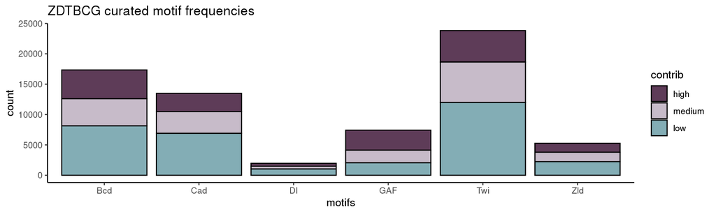

```r
ggplot(motifs_curated.gr %>% as.data.frame, aes(x = pattern_name))+
  geom_bar(aes(fill = factor(contrib_weighted_cat, levels = c('high','medium','low'))), color = 'black')+
  scale_fill_manual(values = rev(c('#83adb5', '#c7bbc9', '#5e3c58')), name = 'contrib')+
  scale_x_discrete(name = 'motifs')+
  ggtitle('ZDTBCG curated motif frequencies')+
  theme_classic()
```

## Double check motif overlaps

Ensure that there isn’t an overrepresentation of unexpected overlapping motif pairs. We expect some overlaps, but checking to make sure that our curations are consistent. Here, we will filter out the longer motifs because we know that those overlaps will be highly represented.

```r
short_motifs.gr<-motifs_curated.gr
overlapping_motifs.gr<- short_motifs.gr %>%
  GenomicRanges::reduce(ignore.strand = T) %>%
  plyranges::mutate(motif_island_id = 1:length(.))
overlapping_motifs.ov<-findOverlaps(short_motifs.gr, overlapping_motifs.gr, ignore.strand = T)
assert('IDs do not allow indexing shortcut.', 1:length(short_motifs.gr)==overlapping_motifs.ov@from)
short_motifs.gr$motif_island_id<-overlapping_motifs.ov@to

#Group motifs by their island ID and display frequency of motif contents
grouped_motif_content.df<-short_motifs.gr %>% as.data.frame %>%
  dplyr::group_by(motif_island_id) %>%
  dplyr::summarize(motif_content = paste0(sort(pattern_name), collapse = '_'))

grouped_motif_content.df$motif_content %>% table() %>% sort(decreasing = T) %>% .[1:30]
```

```
## .
##         Twi         Bcd         Cad         GAF         Zld          Dl
##       23498       17179       13372        7317        5210        1865
##     Cad_Twi     Bcd_Twi      Dl_Twi     Twi_Twi     Bcd_Cad     GAF_Twi
##          58          50          50          45          41          41
##      Bcd_Dl     Twi_Zld     Bcd_GAF     GAF_GAF     Bcd_Zld     GAF_Zld
##          33          21          18          14          12          12
##      Cad_Dl     Cad_GAF     Cad_Zld  Bcd_Dl_Twi Cad_Twi_Twi      Dl_GAF
##           7           6           3           2           2           2
##      Dl_Zld  Bcd_Bcd_Dl Bcd_Bcd_Twi Bcd_Bcd_Zld Bcd_Cad_Twi Bcd_GAF_GAF
##           2           1           1           1           1           1
```

Here we can see that the most frequent motif overlaps occur at very low rates which will not throw off analysis.

# Annotate motifs by their collected regional grouping

Because we took motifs based on their relative contribution and not the featured `example_idx` column, we need a new grouping annotation to define the motifs when we are conducting perturbations and other grouping systems. We will call this index `region_id`.

```r
islands.gr<-resize(motifs_curated.gr, 200, 'center') %>%
  GenomicRanges::reduce(ignore.strand = T) %>%
  plyranges::mutate(region_id = 0:(length(.)-1)) #Make region_id 0-based in order to be compatible with BPNet indexing properties.
ov<-findOverlaps(motifs_curated.gr, islands.gr, ignore.strand = T)
testit::assert(ov@from %>% unique %>% length == ov@from %>% length)

#Show hoy many motifs there are per window
ov@to %>% table %>% table
```

```
## .
##     1     2     3     4     5     6     7     8     9    10    11    12    13
## 28097  9921  3436  1361   543   224   100    51    23    11     4     6     1
##    14
##     1
```

```r
#Assign region_id to these motifs
motifs_curated.gr$region_id<-islands.gr$region_id[ov@to]
motifs_curated.gr$region_start_1based<-islands.gr[ov@to] %>% resize(., 1000, 'center') %>% start()
motifs_curated.gr$region_end_1based<-islands.gr[ov@to] %>% resize(., 1000, 'center') %>% end()

#Assert that all motifs are incorporated.
testit::assert('All motifs have a correct region', all(overlapsAny(motifs_curated.gr, resize(islands.gr, 1000, 'center'))))

#Export regions in 0-based coordinates
islands.gr<-islands.gr %>% resize(., 1000, 'center')
rtracklayer::export(islands.gr %>% plyranges::mutate(name = region_id), 'bed/mapped_motifs/all_grouped_regions_0based.bed', format = 'BED')
```

# Export curated motifs

In the subsequent .bed file it will be the `[task]_[motif_id]_[region_id]` naming convention.

```r
motifs_curated.df<-motifs_curated.gr %>% as.data.frame()
readr::write_tsv(motifs_curated.df, 'tsv/mapped_motifs/all_instances_curated_1based.tsv.gz')
rtracklayer::export(motifs_curated.gr %>%
                      plyranges::mutate(name = paste0(pattern_name, '_', motif_id, '_', region_id)) %>%
                      GenomicRanges::sort(ignore.strand = T),
                    'bed/mapped_motifs/all_instances_curated_0based.bed', format = 'BED')
```

In conclusion, motifs were curated based on redundancies and saved to 1-based and 0-based coordinates. These will be the reference motifs that we base subsequent analysis on.

# Export Zelda motif sequences

In order to further investigate Zelda motif sequences, generate the underlying sequences across Zelda binding motifs mapped.

```r
zld_seqs.df<-motifs.gr %>% dplyr::filter(pattern_name == 'Zld') %>%
  getSeq(bsgenome, ., as.character = TRUE) %>%
  table(.) %>%
  sort(., decreasing = T) %>%
  as.data.frame
colnames(zld_seqs.df)<-c('seq', 'freq')
readr::write_tsv(zld_seqs.df, 'tsv/binding_zld_seq_freqs.tsv')
```

# Export motifs that overlap with ATAC-seq regions

In order to investigate the effects of motifs across accessible regions, export motifs that are overlapping with ATAC-seq peaks.

```r
motifs_curated.gr %>%
  .[overlapsAny(., rtracklayer::import(atac_peaks), type = 'within', ignore.strand = T)] %>%
  as.data.frame(.) %>%
  readr::write_tsv(., 'tsv/mapped_motifs/atac_overlapping_instances_curated_1based.tsv.gz')
```